# Reproducible Reseach with Quarto

Demo for BDSI Workshop

Authors

Emi Tanaka

Australian National University

Chat GPT

Date

12th April 2024 *(Last modified: 10th April 2024)*

Executive Summary

Reproducible research is indispensable for ensuring the trustworthiness of scientific findings. This abstract explores its significance, emphasizing open access to data, code, and documentation. Key practices such as version control and reproducible environments are highlighted for their role in enhancing verifiability. Additionally, the integration of reproducibility criteria in peer review is discussed. Overall, reproducible research serves as a vital framework for advancing scientific knowledge with transparency and integrity.

Keywords

reproducible research, quarto, markdown

## 1 Introduction

Reproducible research refers to the practice of making research methods, data, and results transparent and accessible so that others can verify and replicate the findings. The goal of reproducibility is to ensure that scientific findings are trustworthy and can be independently validated.

## 2 Key insight

Quarto (Allaire and Dervieux 2024) can seamless integrate code, text, and output in a single document, facilitating transparency and reproducibility. Quarto allows researchers to combine code from various programming languages (such as R, Python, or Julia) with explanatory text and resulting visualizations or analyses. This integration ensures that the entire research process, from data analysis to interpretation, can be easily replicated by others.

## 3 Results

Data plots can be easily replicated if the plots are produced with the `ggplot2` R package (Wickham 2016). For example, Figure 1 has been produced using `ggplot2`.

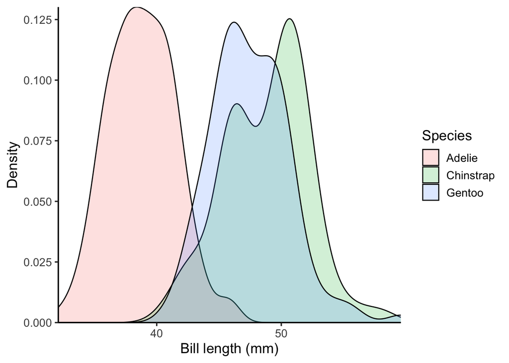

## 4 Conclusion

Reproducible research not only fosters trust in scientific findings but also promotes collaboration and innovation by allowing others to build upon existing research. Many journals and funding agencies now require or encourage researchers to adopt reproducible practices to improve the reliability and credibility of scientific research.

## References

Allaire, JJ, and Christophe Dervieux. 2024. *Quarto: R Interface to ’Quarto’ Markdown Publishing System*. https://CRAN.R-project.org/package=quarto.

Wickham, Hadley. 2016. *Ggplot2: Elegant Graphics for Data Analysis*. Springer-Verlag New York. https://ggplot2.tidyverse.org.